# Trundler Report Template

## Import libraries

```r
library(trundler)
library(dplyr)
library(stringr)
library(purrr)
library(tidyr)
library(ggplot2)
```

## Set the API key

If you don’t have an API key yet, you can get one from [RapidAPI](https://rapidapi.com/datawookie/api/trundler).

```r
API_KEY <- Sys.getenv("TRUNDLER_KEY")
set_api_key(API_KEY)
```

## View catalog of retailers

Here’s a look at the first 10 retailers in the catalog

```r
# Get a dataframe of all available retailers
retailer_df <- retailer()

# View the first 10 retailers
head(retailer_df, n = 10)
```

```
# A tibble: 10 x 5
   retailer_id retailer         retailer_url                    currency visible
         <int> <chr>            <chr>                           <chr>    <lgl>
 1           1 EEM Technologies https://www.eemtechnologies.co… USD      TRUE
 2           2 Clicks           https://clicks.co.za/           ZAR      TRUE
 3           3 Dischem          https://www.dischem.co.za/      ZAR      TRUE
 4           4 Game             https://www.game.co.za/         ZAR      TRUE
 5           5 Woolworths       https://www.woolworths.co.za/   ZAR      TRUE
 6           6 Fortnum & Mason  https://www.fortnumandmason.co… GBP      FALSE
 7           7 John Lewis       https://www.johnlewis.com/      GBP      FALSE
 8           8 Marks & Spencer  https://www.marksandspencer.co… GBP      FALSE
 9           9 Pick 'n Pay      https://www.pnp.co.za/          ZAR      TRUE
10          10 Makro            https://www.makro.co.za/        ZAR      TRUE
```

## Retrieve data for specific products

Let’s say you’re interested in the price of Bovril at Pick ’n Pay. You can use the retailer ID for Pick ’n Pay (9) to search for all Bovril products at Pick ’n Pay.

```r
# Search for Bovril products.
retailer_products(retailer_id = 9, product = "Bovril")
```

```
# A tibble: 4 x 5
  product_id product                       brand model sku
       <int> <chr>                         <chr> <chr> <chr>
1     543374 Bovril Beefy Spread 250g      <NA>  <NA>  000000000000201870_EA
2     543996 Bovril Beefy Spread 125g x 40 <NA>  <NA>  000000000000174911_CS
3     544569 Bovril Beefy Spread 125g x 5  <NA>  <NA>  000000000000174911_CK
4     544570 Bovril Beefy Spread 125g      <NA>  <NA>  000000000000174911_EA
```

Pick ‘n Pay sells a few different Bovril products. Let’s choose ’Bovril Beefy Spread 250g’. Using the corresponding product ID, you can get the product and price data you’re interested in.

```r
# Get the product data
bovril_250g <- product(543374)

# Add the historical price data and the retailer information
bovril_250g_prices <- product_prices(543374) %>%
  inner_join(bovril_250g, by = 'product_id') %>%
  inner_join(retailer_df, by = 'retailer_id') %>%
  select(date = time, product, retailer, starts_with('price')) %>%
  mutate(date = as.Date(date))
```

Let’s take a look at the most recent price records.

```
# A tibble: 6 x 6
  date       product             retailer  price price_promotion price_effective
  <date>     <chr>               <chr>     <dbl>           <dbl>           <dbl>
1 2020-08-25 Bovril Beefy Sprea… Pick 'n …  52.0              NA            52.0
2 2020-08-22 Bovril Beefy Sprea… Pick 'n …  52.0              NA            52.0
3 2020-08-20 Bovril Beefy Sprea… Pick 'n …  52.0              NA            52.0
4 2020-08-18 Bovril Beefy Sprea… Pick 'n …  52.0              NA            52.0
5 2020-08-15 Bovril Beefy Sprea… Pick 'n …  52.0              NA            52.0
6 2020-08-13 Bovril Beefy Sprea… Pick 'n …  52.0              NA            52.0
```

Now that we have the data, we can plot it!

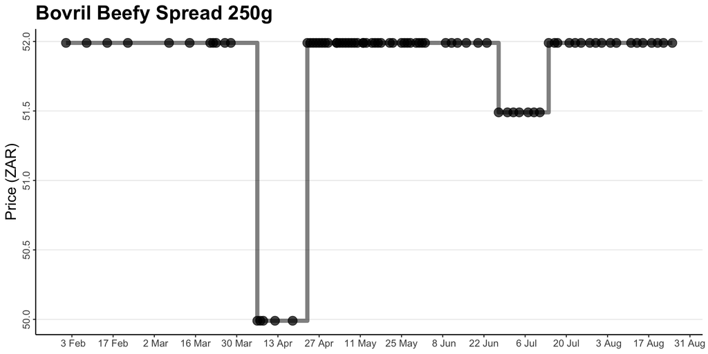

## Get the average prices for a range of products

To get the average prices for a particular product or product category, a little more manipulation is required.

Let’s say that you want to create an average price plot for single pineappples.

First, you’ll need to get the data for the products you want to aggregate.

```r
# Search the database
search_results <- products("pineapple")

# Join the search results to the retailer dataframe, use only single pineapples at South African retailers.
pineapple_products <- search_results %>%
  inner_join(retailer_df, by = 'retailer_id') %>%
  filter(str_detect(product, "Single"),
         currency == "ZAR")

# View the results
pineapple_products %>% select(product, product_id, sku, retailer, everything())
```

```
# A tibble: 4 x 10
  product product_id sku   retailer retailer_id brand model retailer_url
  <chr>        <int> <chr> <chr>          <int> <chr> <chr> <chr>
1 Single…     720591 2001… Woolwor…           5 Wool… <NA>  https://www…
2 Pineap…    2256134 1015… Checkers          95 <NA>  <NA>  https://www…
3 Medium…    2256694 1014… Checkers          95 <NA>  <NA>  https://www…
4 Single…    2876701 2001… Woolwor…           5 Wool… <NA>  https://www…
# … with 2 more variables: currency <chr>, visible <lgl>
```

At a first glance, it looks like there are four distinct products, but there are actually two ‘Single Queen Pineapple’ products from Woolworths. These products have the same SKU (Shop Keeping Unit) but different product IDs.

When a retailer changes the way that a product is listed in their catalog, the product is assigned a new ID, but the SKU stays consistent.

It’s important to retain both product IDs because each ID is associated with a different period in that product’s price history. To get the full price history, combine the data associated with each product ID. Here’s one way to do this:

```r
# Get the price data for these pineapple products
pineapple_prices <- map_dfr(pineapple_products$product_id, product_prices) %>%
  unnest(cols = c(price)) %>%
  mutate(date = as.Date(time)) %>%
  inner_join(pineapple_products, by = 'product_id') %>%
  select(date, product_id, sku, product, retailer, starts_with("price"))

# Consolidate the product price if any products have more than one product ID
pineapple_consolidated <- pineapple_prices %>%
  group_by(date, sku) %>%
  summarise(price = mean(price), .groups = "drop")
```

Here are the first records of the consolidated pineapple prices dataframe.

```
# A tibble: 6 x 3
  date       sku      price
  <date>     <chr>    <dbl>
1 2020-02-08 20016814  18.0
2 2020-02-14 20016814  18.0
3 2020-02-28 20016814  20.0
4 2020-03-13 20016814  23.0
5 2020-03-14 20016814  23.0
6 2020-03-16 20016814  23.0
```

As you can see, the date intervals are irregular. You can interpolate prices for any missing days. Then, you’ll be able to get the average price of all single pineapples on each day.

```r
# First, create a uniform sequence of dates
dates <- seq.Date(
  min(pineapple_consolidated$date),
  max(pineapple_consolidated$date),
  by = "day"
)

# Expand to cover full date range, interpolate prices for missing dates, and get the average price for each day
pineapple_summary <- complete(pineapple_consolidated, date = dates, nesting(sku)) %>%
  group_by(sku) %>%
  mutate(price_interpolate = approx(date, price, date, method = "constant", rule = 2)$y) %>%
  group_by(date) %>%
  summarise(avg_price = mean(price_interpolate))
```

Now, there’s an average price for each date, and you can plot the data.

```
# A tibble: 6 x 2
  date       avg_price
  <date>         <dbl>
1 2020-02-08      20.7
2 2020-02-09      20.7
3 2020-02-10      20.7
4 2020-02-11      20.7
5 2020-02-12      20.7
6 2020-02-13      20.7
```

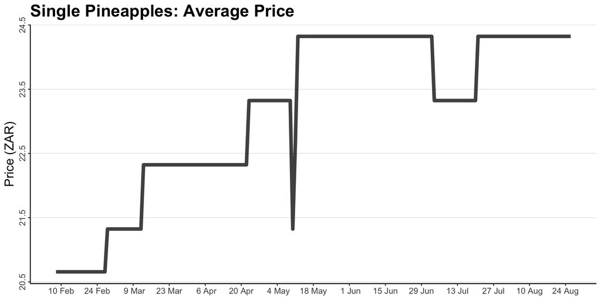